# How Transparency Policies Shape the Global Influence of Authoritarian Regimes on Social Media

Allison Koh

Centre for Artificial Intelligence in Government at

[figure not shown]

ISA — March 5, 2025

## #TBT

> **“We believe that people have the right to know when a media account is affiliated directly or indirectly with a state actor.”**

*– Twitter 2020*

## #TBT

[figure not shown]

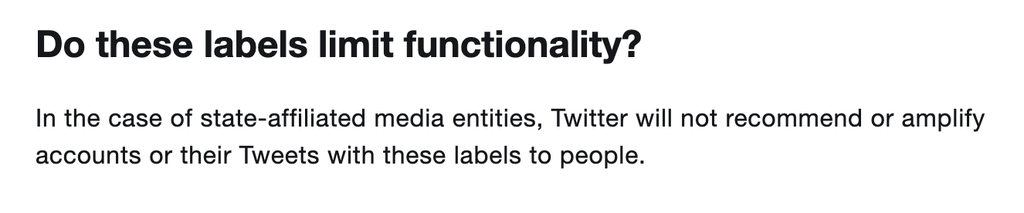

Sources: Internet Archive, Twitter

## #TBT

[figure not shown]

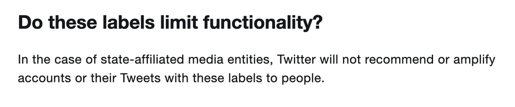

Sources: Internet Archive, Twitter

## The “After Times” of Twitter

### March 29, 2023

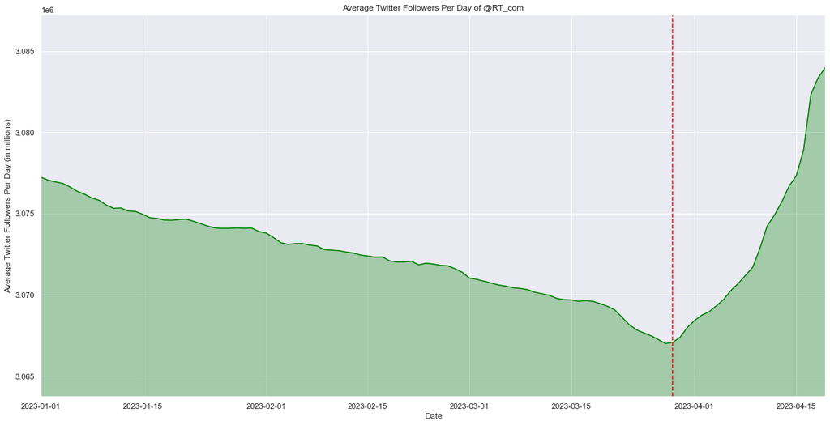

Source: Digital Forensic Research Lab

## The “After Times” of Twitter

### April 21, 2023

[figure not shown]

[figure not shown]

## Who was affected by these policy shifts?

[figure not shown]

Official government and diplomatic accounts

- Voices of the nation-state abroad
- Highly visible *regardless* of labels

[figure not shown]

State-affiliated media

- *Not* editorially independent from the state
- Less attributable to the state without labels

## Theoretical Expectation

## Erosion of transparency policies ⬇️ State actors took advantage of new opportunities for **authoritarian image management**. ⬇️ They gained influence on the platform.

## Comparative Analyses

### 🔎 Expectations: State Actor Types

State actors with high visibility will be less responsive to platform changes.

- 🏦 Official government accounts more visible *regardless of profile label*.
- 📺 State-affiliated media have more opportunities to obscure their links to state sponsorship.

### 🌏 Exploratory Analysis: Country

Do we observe differences in online behavior/engagement across countries?

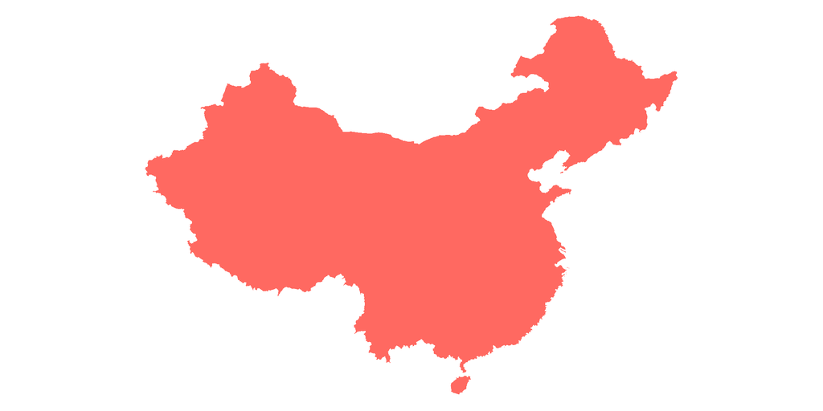

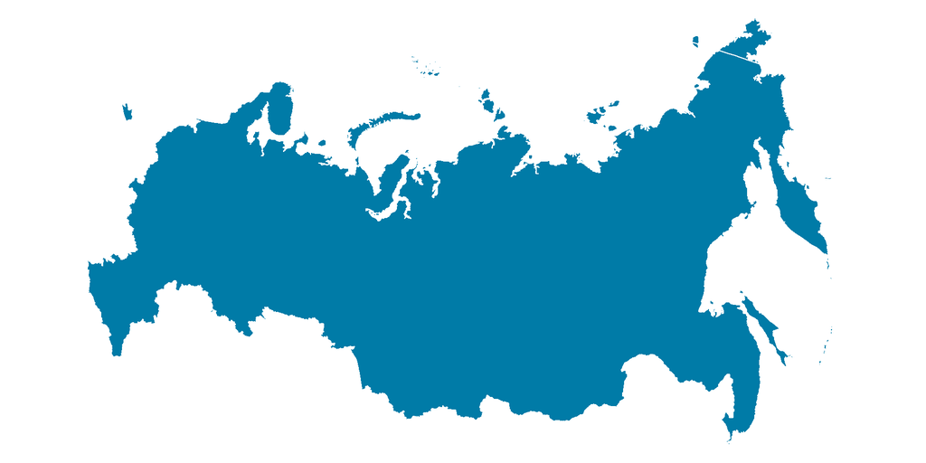

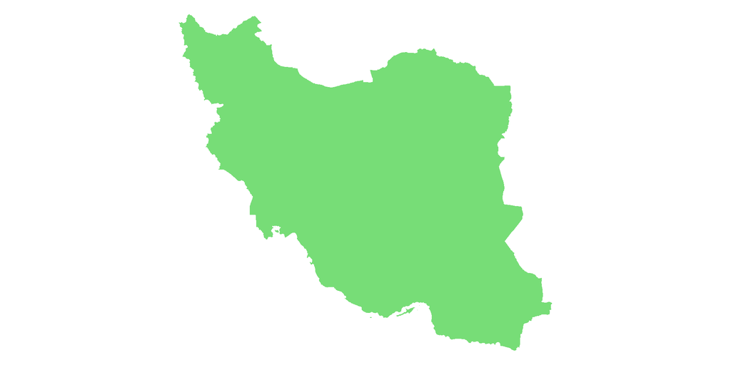

## Data

### 🏦📺 State Actors: Hamilton 2.0 Dashboard<sup>1</sup>

- 1,177 accounts linked to Chinese, Iranian, and Russian state actors
- Proxy for accounts that had government and state-affiliated media labels

### Twitter Academic API via `twarc` CLI

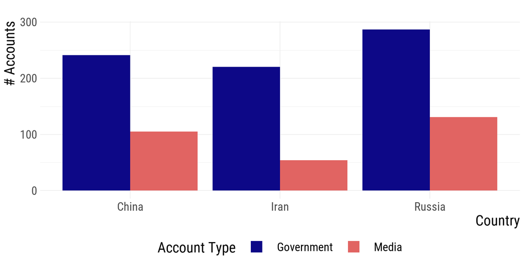

Tweet timeline endpoint; up to ~3,200 tweets per account  
Collected ~2.5 million tweets from 1,038 timelines

[^1]: Schafer (2019)

## Measurement

### 💻 Method

- Generalized Synthetic Control (Xu 2017), ITSA, RDD

## Results: Actor Type

⬆️ engagement with media; 🕸️ consolidation of messaging after label removal

Daily-aggregated totals/averages

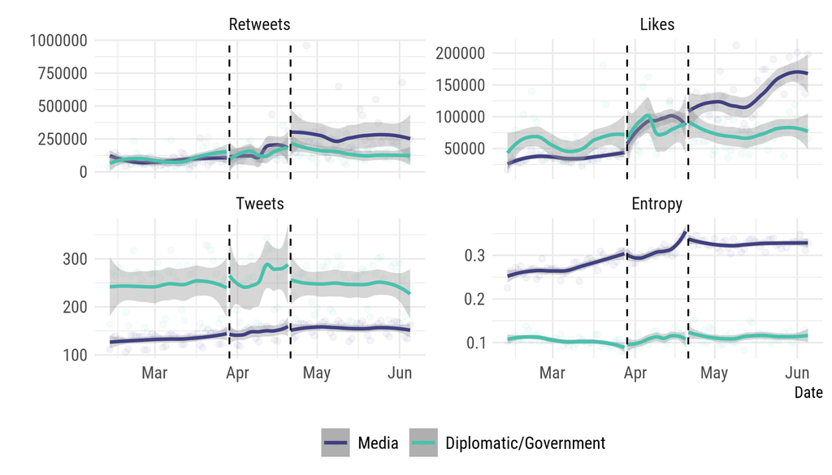

## Results: Actor Type + Country

⬆️ engagement with Russian accounts; $\Delta$ user behavior of Chinese + Russian accounts

Daily-aggregated totals/averages

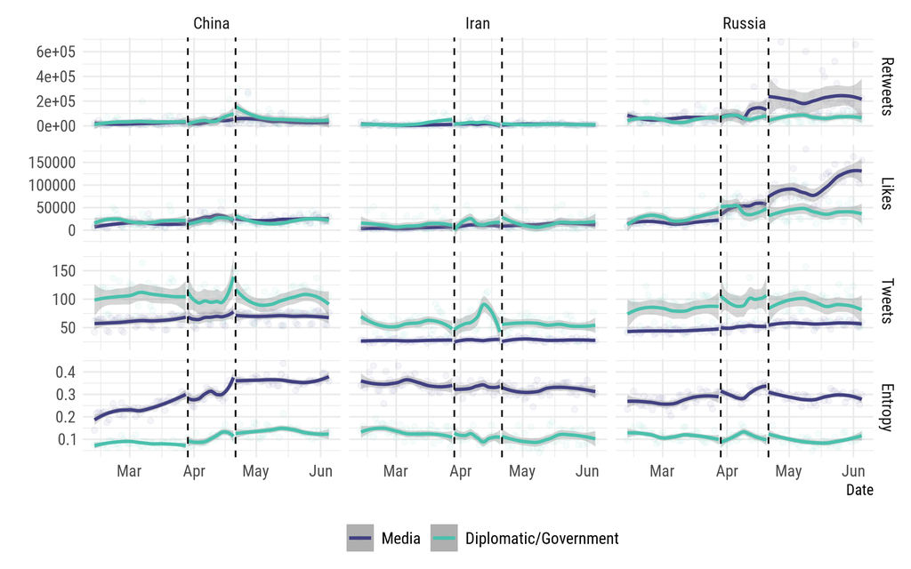

## Takeaways

### Findings

After Twitter’s erosion of transparency policies for state actors…

1. Notable increases in engagement with media after 2 major policy changes
2. Messaging was (slightly) consolidated after label removal
3. Of the three countries, Russia benefited the most from these policy changes<sup>1</sup>.

### Next Steps

- Finalizing model specs
- Adjusting the primary approach for content analyses
[^2]: Chinese accounts significantly changed user behavior but did not observe (as) significant gains in engagement.

# Thank you!

a.w.koh@bham.ac.uk

https://allisonkoh.github.io/

🦋 @allisonwkoh

# Appendix

## Twitter: A safe space for state influence?

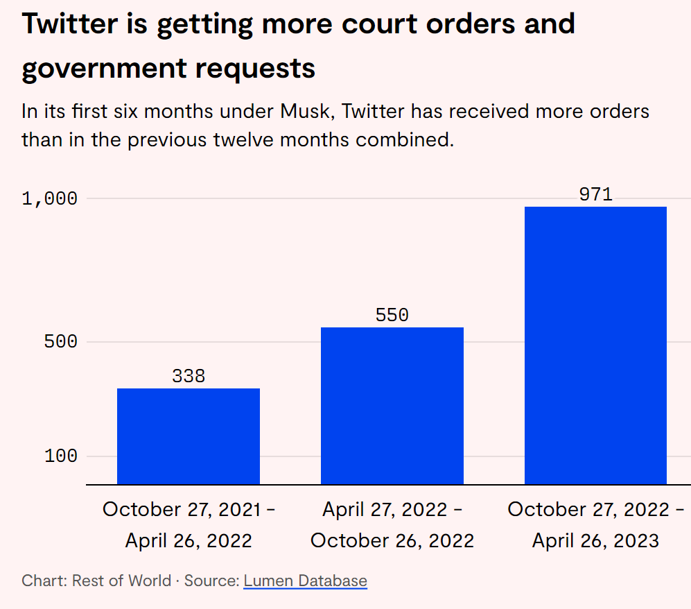

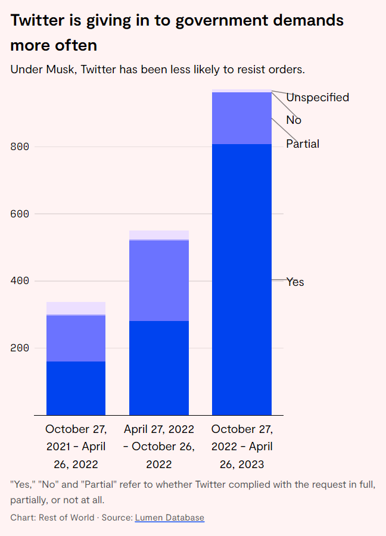

Source: Rest of World, Lumen Database

## Twitter’s Policy Changes in April 2023

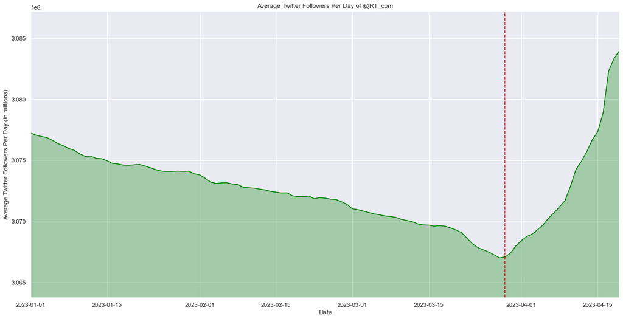

**March 29:** ⬆️ engagement with prominent state media from China, Russia, Iran (Kann 2023)

**April 6:** “In the case of state-affiliated media entities, Twitter will not recommend or amplify accounts or their Tweets with these labels to people.”

[figure not shown]

**April 12:** NPR quits Twitter after being labeled as “state-affiliated media” (Folkenflik 2023)

[figure not shown]

**April 21:** Twitter removes all labels for “government” and “state-affiliated media”

Sources: DFRLab, Twitter, Internet Archive

## Research Questions and Definitions

### ❓ Research Questions

After Twitter’s removal of profile labels on April 21st, 2023…

- …did engagement with state actors increase?
- …did state actors change how they use the platform?

### 📖 Definitions<sup>1</sup>

- **State actor:** Any individual or entity connected to government or state-affiliated media
- **Government official:** Key individuals/entities representing “voices of the nation state abroad”
- **State-affiliated media:** Outlets where the state exercises control over editorial content
[^3]: Schafer (2019); Twitter (2020)

## Data on State Actors

### Hamilton 2.0 Dashboard<sup>1</sup>

[figure not shown]

1,177 accounts linked to Chinese, Iranian, and Russian state actors  
Proxy for accounts that had government and state-affiliated media labels

[^4]: Schafer (2019)

## Measurement

### Dependent variables

Per-day metrics 📈

- **Retweets** and **likes** of tweets authored by state actors (H1)
- **Tweet volumes** and **“focus”**<sup>1</sup> of posts produced by state actors (H2)

### Independent variables

- State actor type (official government or state-affiliated media)
- Time-related variables for parametric tests
[^5]: *Focus* = inverse topic diversity, see Munger et al. (2019) for another interesting application of this metric in a similar context.

## Results

### Null results at the aggregate level

Placebo Tests—Engagement and Tweet Volume

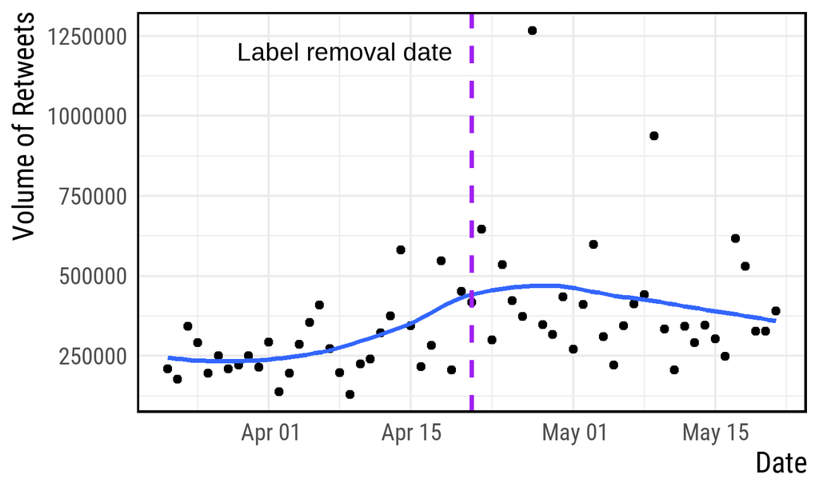

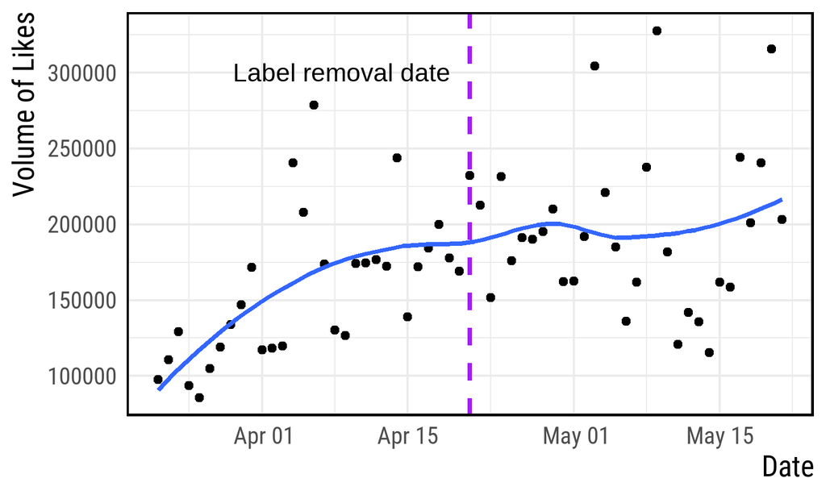

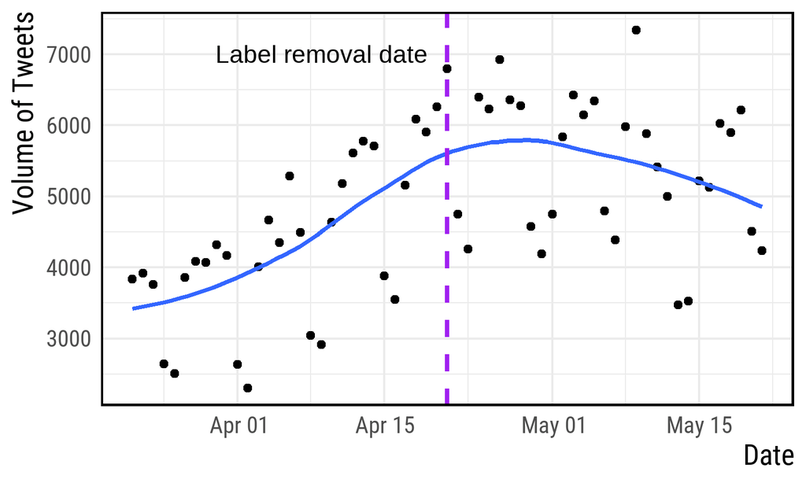

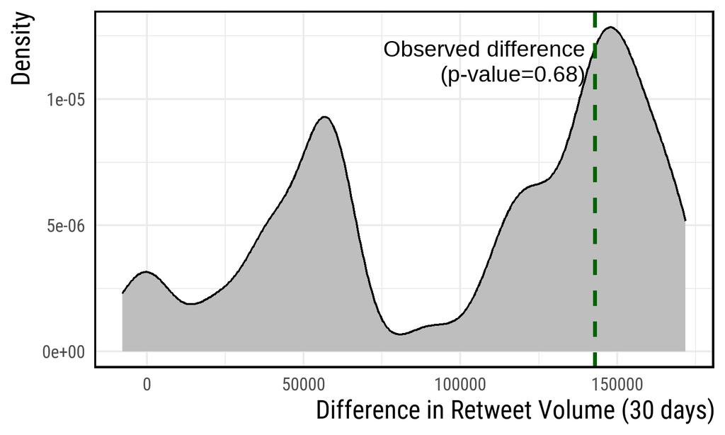

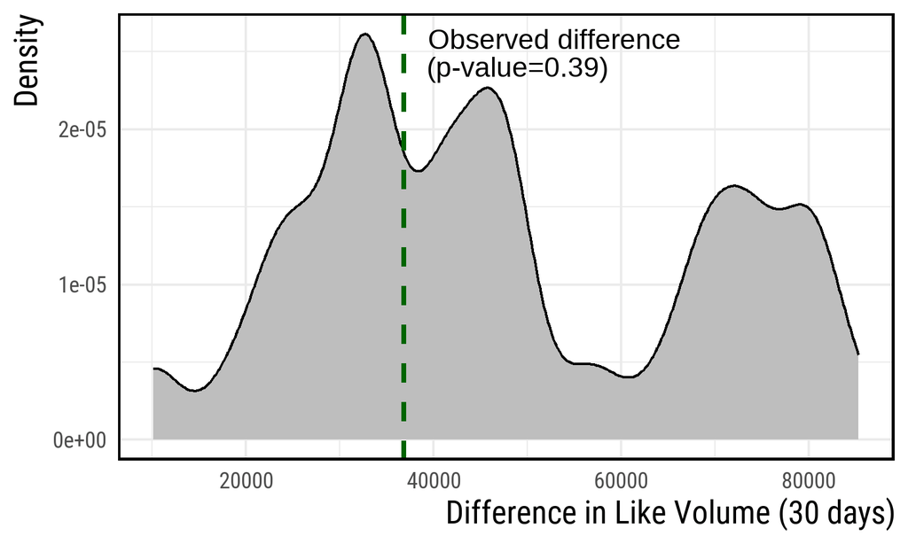

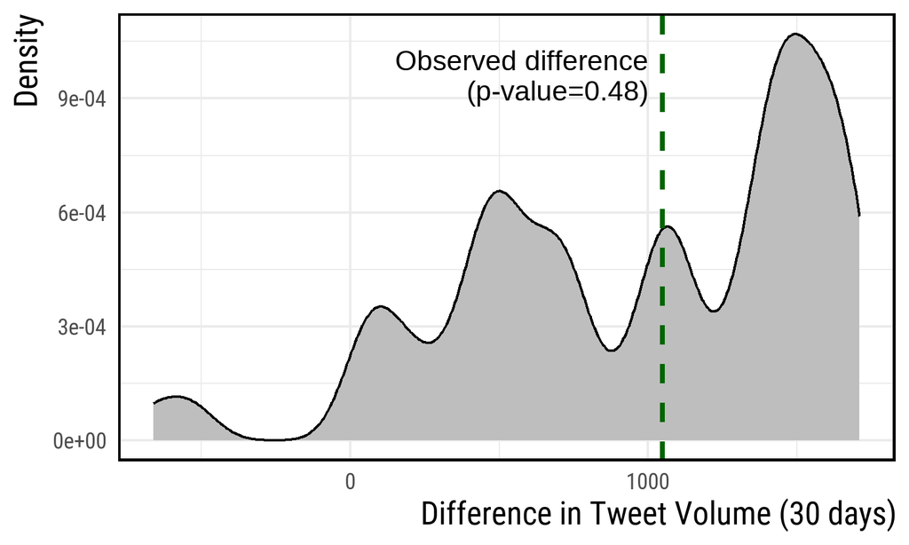

## Results - Synthetic Control

### All State Actors

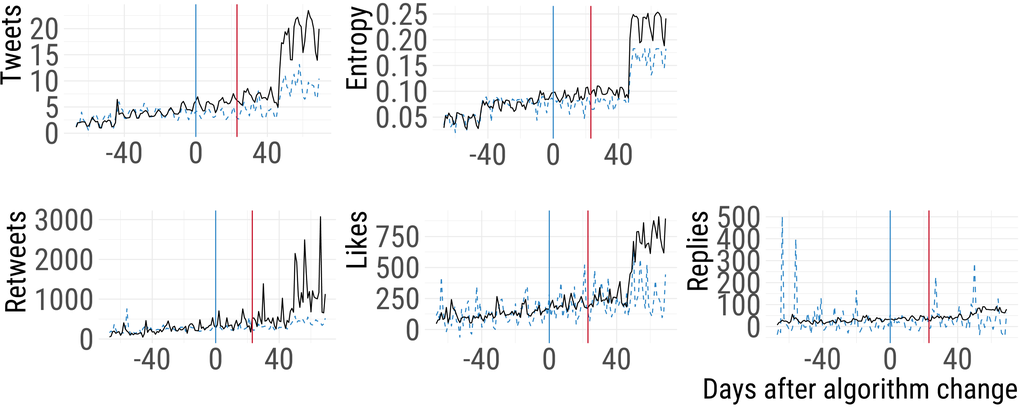

## Results - Synthetic Control

### State Actor Type

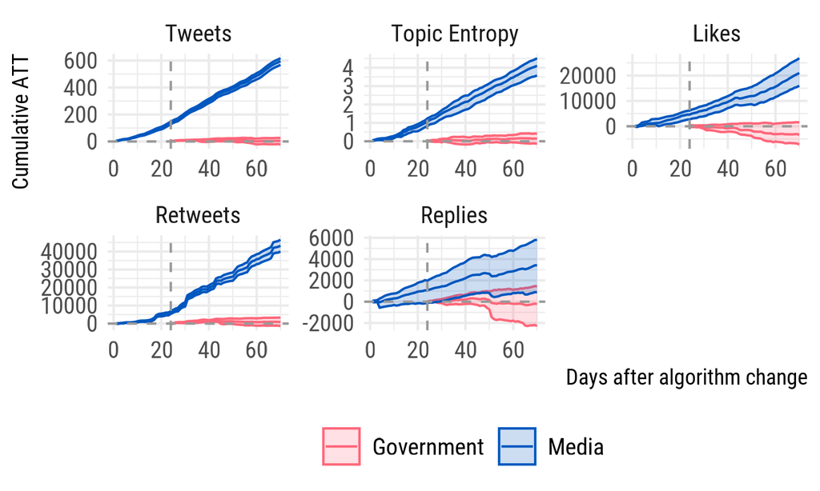

## Results - Synthetic Control

### State Actor Type + Country

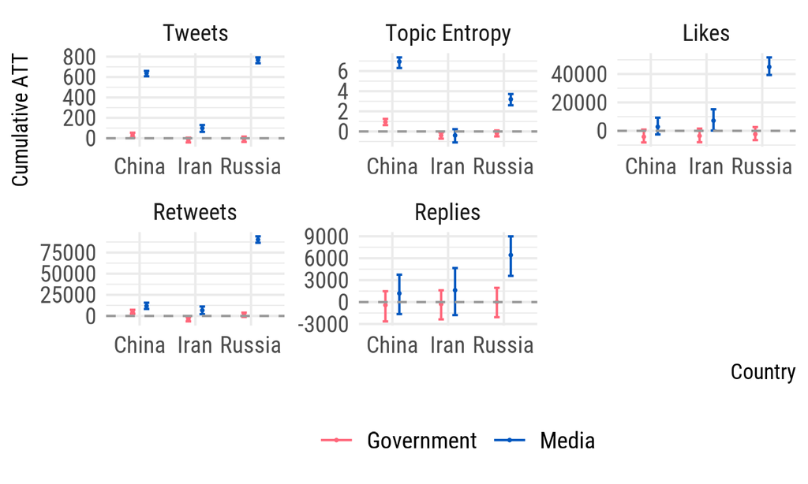